### 5월/3주

#### ▶ ▣ 정당지지도 ▣

더불어민주당 37.7%, 국민의힘 34.8%, 조국혁신당 10.7%, 개혁신당 4.8%, 그 외 다른 정당 2.6%, 지지하는 정당 없다 8.4%, 잘 모르겠다 1.1%

#### ▶ ▣ 대통령 국정 수행 평가 ▣

잘하고 있다 31.1%, 잘못하고 있다 66.3%, 잘 모르겠다 2.6%

#### ☑ ▣ 차기 대권 주자 적합도 ▣

김동연 2.6%, 안철수 1.6%, 오세훈 3.9%, 원희룡 4.6%, 이재명 38.6%, 이준석 4.1%, 조국 7.7%, 한동훈 25.1%, 홍준표 4.2%, 그 외 다른 인물 1.4%, 없다 4.7%, 잘 모르겠다 1.4%

#### ☑ ▣ 윤 대통령 대국민 기자회견 평가 ▣

매우 긍정적이다 17.0%, 약간 긍정적이다 16.3%, 약간 부정적이다 8.5%, 매우 부정적이다 52.9%, 잘 모르겠다 5.3%

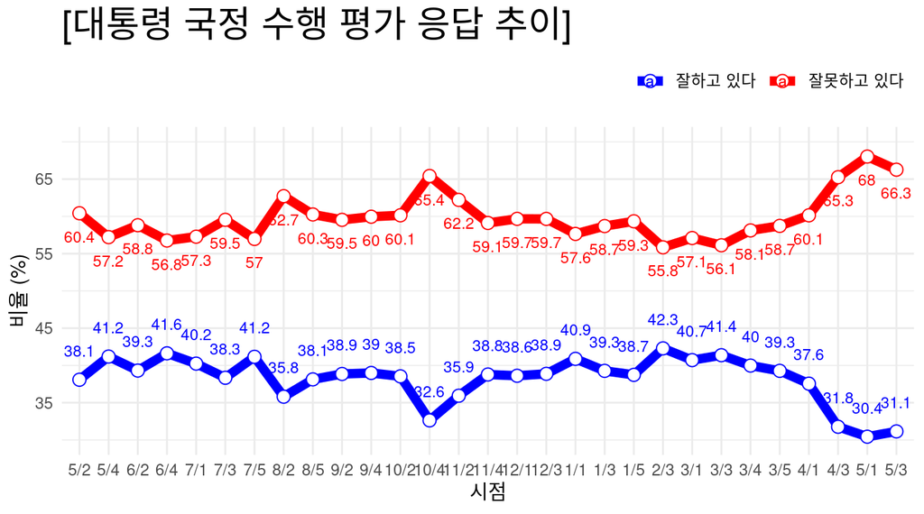

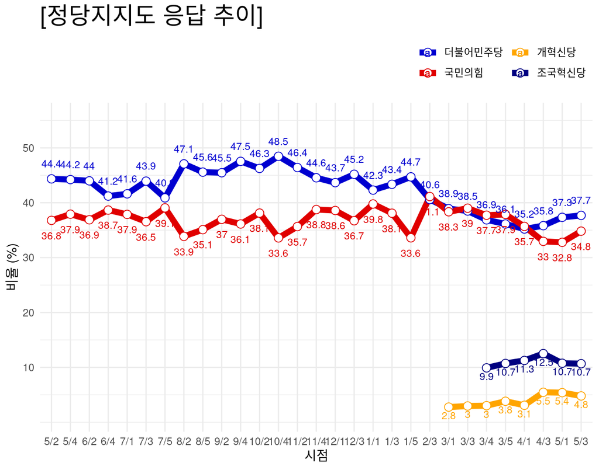

### 추가사항

- [주요질문 / 집단별 세부통계 보기](https://modernity.shinyapps.io/survey_str/) (링크누르시오)

### 참고사항

- 표본수: 2,002명,표본오차는 95% ±2.2%p
- 조사정보: 스트레이트뉴스의 의뢰로 조원씨앤아이가 2024년 5월 11일~13일 3일간

  전국 만 18세 이상 남녀를 대상으로 ARS 여론조사

  (휴대전화 100% RDD 방식, 성,연령대,지역별 비례할당 후 무작위 추출)를 실시한 결과이며,

  표본수는 2,002(총 통화시도 87,448명, 응답률 2.3%)

  ※ 가중치 부여 방식: [림가중] 성별, 연령별, 지역별 가중값 부여(2024년 4월말 행정안전부 발표 주민등록인구기준)
- [중앙선거여론조사심의위원회](https://nesdc.go.kr/portal/bbs/B0000005/list.do?menuNo=200467)에서 관련사항 확인가능

2024.05.14 (Tue) 15:48 제작

- 연구개발 단계입니다.
- 제공: 감동과 마음의 [조원씨앤아이](http://jowoncni.com/html/index.html)